# German Credit Data Exploration_4

Dr. Prashant Mishra

3/27/2018

```r
ml_credit_dataset <- read.csv("ml_credit_dataset.csv")
str(ml_credit_dataset)
```

```
## 'data.frame':    1000 obs. of  87 variables:
##  $ CheckingAccountStatus.0.to.200        : int  0 1 0 0 0 0 0 1 0 1 ...
##  $ CheckingAccountStatus.gt.200          : int  0 0 0 0 0 0 0 0 0 0 ...
##  $ CheckingAccountStatus.lt.0            : int  1 0 0 1 1 0 0 0 0 0 ...
##  $ CheckingAccountStatus.none            : int  0 0 1 0 0 1 1 0 1 0 ...
##  $ Duration.0.to.6                       : int  1 0 0 0 0 0 0 0 0 0 ...
##  $ Duration.6.to.12                      : int  0 0 1 0 0 0 0 0 1 0 ...
##  $ Duration.12.to.18                     : int  0 0 0 0 0 0 0 0 0 0 ...
##  $ Duration.18.to.24                     : int  0 0 0 0 1 0 1 0 0 0 ...
##  $ Duration.24.to.30                     : int  0 0 0 0 0 0 0 0 0 1 ...
##  $ Duration.30.to.36                     : int  0 0 0 0 0 1 0 1 0 0 ...
##  $ Duration.36.to.42                     : int  0 0 0 1 0 0 0 0 0 0 ...
##  $ Duration.42.to.48                     : int  0 1 0 0 0 0 0 0 0 0 ...
##  $ Duration.48.to.54                     : int  0 0 0 0 0 0 0 0 0 0 ...
##  $ Duration.54.to.60                     : int  0 0 0 0 0 0 0 0 0 0 ...
```

[output cut: 73 more lines]

# Making a Machine Learning task using mlr

```r
library(mlr)
credit.task = makeClassifTask(data = ml_credit_dataset, target = "Class")
credit.task = removeConstantFeatures(credit.task)
credit.task
```

```
## Supervised task: ml_credit_dataset
## Type: classif
## Target: Class
## Observations: 1000
## Features:
##    numerics     factors     ordered functionals
##          86           0           0           0
## Missings: FALSE
## Has weights: FALSE
## Has blocking: FALSE
## Has coordinates: FALSE
## Classes: 2
##  Bad Good
##  300  700
## Positive class: Bad
```

# Cost-sensitive classification

-In regular classification the aim is to minimize the misclassification rate and thus all types of misclassification errors are deemed equally severe.

-A more general setting is cost-sensitive classification where the costs caused by different kinds of errors are not assumed to be equal and the objective is to minimize the expected costs.

-In case of class-dependent costs the costs depend on the true and predicted class label. The costs c(k,l) for predicting class k if the true label is l are usually organized into a K×K cost matrix where K is the number of classes.

-Naturally, it is assumed that the cost of predicting the correct class label y is minimal (that is c(y,y)≤c(k,y) for all k=1,…,K).

# Class-dependent misclassification costs

-There are some classification methods that can accomodate misclassification costs directly. One example is rpart.

-Alternatively, we can use cost-insensitive methods and manipulate the predictions or the training data in order to take misclassification costs into account. mlr supports $\textbf{ thresholding }$ and $\textbf{ rebalancing }$.

-$\textbf{Thresholding: }$ The thresholds used to turn posterior probabilities into class labels, are chosen such that the costs are minimized. This requires a Learner that can predict posterior probabilities. During training the costs are not taken into account.

-$\textbf{Rebalancing: }$ The idea is to change the proportion of the classes in the training data set in order to account for costs during training, either by $\textem{weighting}$ or by $\textem{sampling}$. Rebalancing does not require that the Learner can predict probabilities.

—– For weighting we need a Learner that supports class weights or observation weights.

—– If the Learner cannot deal with weights the proportion of classes can be changed by over- and undersampling.

Cost Matrix for German Credit Data

```r
costs = matrix(c(0, 1, 5, 0), 2)
colnames(costs) = rownames(costs) = getTaskClassLevels(credit.task)
costs
```

```
##      Bad Good
## Bad    0    5
## Good   1    0
```

So, the maximum cost is 5 and minimum 0. We penalize if the true class was “Bad” but the model predicts “Good”.

# 1. Thresholding

We start by fitting a logistic regression model to the German credit data set and predict posterior probabilities.

```r
logisticLrn = makeLearner("classif.multinom", predict.type = "prob")

logisticModel = mlr::train(logisticLrn, credit.task)
logisticpred = predict(logisticModel, task = credit.task)

logisticpred
```

```
## Prediction: 1000 observations
## predict.type: prob
## threshold: Bad=0.50,Good=0.50
## time: 0.01
##   id truth   prob.Bad prob.Good response
## 1  1  Good 0.02001323 0.9799868     Good
## 2  2   Bad 0.74111232 0.2588877      Bad
## 3  3  Good 0.03363280 0.9663672     Good
## 4  4  Good 0.10402736 0.8959726     Good
## 5  5   Bad 0.67594919 0.3240508      Bad
## 6  6  Good 0.18333223 0.8166678     Good
## ... (#rows: 1000, #cols: 5)
```

We also fit the data with C50 alogorithm.

```r
c50Lrn = makeLearner("classif.C50", predict.type = "prob")
c50Model = mlr::train(c50Lrn, credit.task)
c50pred = predict(c50Model, task = credit.task)
c50pred
```

```
## Prediction: 1000 observations
## predict.type: prob
## threshold: Bad=0.50,Good=0.50
## time: 0.16
##   id truth   prob.Bad prob.Good response
## 1  1  Good 0.06571429 0.9342857     Good
## 2  2   Bad 0.88750000 0.1125000      Bad
## 3  3  Good 0.08534799 0.9146520     Good
## 4  4  Good 0.04193549 0.9580645     Good
## 5  5   Bad 0.17916667 0.8208333     Good
## 6  6  Good 0.01666667 0.9833333     Good
## ... (#rows: 1000, #cols: 5)
```

# i. Theoretical thresholding

The default thresholds for both classes are 0.5. But according to the cost matrix we should predict class Good only if we are very sure that Good is indeed the correct label. Therefore we should increase the threshold for class Good and decrease the threshold for class Bad.

The theoretical threshold for the positive class in two class case can be calculated from the cost matrix as : $t^* = \frac{c(+1,-1)-c(-1,-1)}{c(+1,-1)-c(+1,+1)+c(-1,+1)-c(-1,-1)}$ This formula comes from the fact that cost of predicting class 1(given the actual is class 1) must be less than cost of predicting -1. $P(j=-1|x)c(+1,-1) + P(j=+1|x)c(+1,+1) \leq P(j=-1|x)c(-1,-1) + P(j=+1|x)c(-1,+1)$ if we take $p = P(j=+1|x)$ then a threshold value can be derived from, $(1-t^*)c(+1,-1)+t^*c(-1,-1) = (1-t^*)c(-1,-1)+t^*c(-1,+1)$

# Theoretical threshhold

Calculate the theoretical threshold for the positive class: Since c(+1,+1)=c(-1,-1)=0

```r
th = costs[2,1]/(costs[2,1] + costs[1,2])
th
```

```
## [1] 0.1666667
```

-you can change thresholds in mlr either before training by using the “predict.threshold”" option of makeLearner or after prediction by calling setThreshold on the Prediction object.

-Predict class labels according to the theoretical threshold

```r
logisticpred.th = setThreshold(logisticpred, th)
logisticpred.th
```

```
## Prediction: 1000 observations
## predict.type: prob
## threshold: Bad=0.17,Good=0.83
## time: 0.01
##   id truth   prob.Bad prob.Good response
## 1  1  Good 0.02001323 0.9799868     Good
## 2  2   Bad 0.74111232 0.2588877      Bad
## 3  3  Good 0.03363280 0.9663672     Good
## 4  4  Good 0.10402736 0.8959726     Good
## 5  5   Bad 0.67594919 0.3240508      Bad
## 6  6  Good 0.18333223 0.8166678      Bad
## ... (#rows: 1000, #cols: 5)
```

```r
c50pred.th = setThreshold(c50pred, th)
c50pred.th
```

```
## Prediction: 1000 observations
## predict.type: prob
## threshold: Bad=0.17,Good=0.83
## time: 0.16
##   id truth   prob.Bad prob.Good response
## 1  1  Good 0.06571429 0.9342857     Good
## 2  2   Bad 0.88750000 0.1125000      Bad
## 3  3  Good 0.08534799 0.9146520     Good
## 4  4  Good 0.04193549 0.9580645     Good
## 5  5   Bad 0.17916667 0.8208333      Bad
## 6  6  Good 0.01666667 0.9833333     Good
## ... (#rows: 1000, #cols: 5)
```

# Creating a cost measure

In order to calculate the average costs over the entire data set we first need to create a new performance Measure. This can be done through function makeCostMeasure. It is expected that the rows of the cost matrix indicate true and the columns predicted class labels.

```r
credit.costs = makeCostMeasure(id = "credit.costs", name = "Credit costs", costs = costs,
  best = 0, worst = 5)
credit.costs
```

```
## Name: Credit costs
## Performance measure: credit.costs
## Properties: classif,classif.multi,req.pred,req.truth,predtype.response,predtype.prob
## Minimize: TRUE
## Best: 0; Worst: 5
## Aggregated by: test.mean
## Arguments: costs=<matrix>, combine=<function>
## Note:
```

# Performace measure : Credit cost and Error

Then the average costs can be computed by function performance. Below we compare the average costs and the error rate (mmce) of the learning algorithm with both default thresholds 0.5 and theoretical thresholds.

Performance with default thresholds 0.5

```r
performance(logisticpred, measures = list(credit.costs, mmce))
```

```
## credit.costs         mmce
##        0.735        0.207
```

```r
calculateConfusionMatrix(logisticpred, relative = TRUE)
```

```
## Relative confusion matrix (normalized by row/column):
##         predicted
## true     Bad       Good      -err.-
##   Bad    0.56/0.69 0.44/0.17 0.44
##   Good   0.11/0.31 0.89/0.83 0.11
##   -err.-      0.31      0.17 0.21
##
##
## Absolute confusion matrix:
##         predicted
## true     Bad Good -err.-
##   Bad    168  132    132
##   Good    75  625     75
##   -err.-  75  132    207
```

```r
performance(c50pred, measures = list(credit.costs, mmce))
```

```
## credit.costs         mmce
##        0.286        0.078
```

```r
calculateConfusionMatrix(c50pred, relative = TRUE)
```

```
## Relative confusion matrix (normalized by row/column):
##         predicted
## true     Bad       Good      -err.-
##   Bad    0.83/0.91 0.17/0.07 0.17
##   Good   0.04/0.09 0.96/0.93 0.04
##   -err.-      0.09      0.07 0.08
##
##
## Absolute confusion matrix:
##         predicted
## true     Bad Good -err.-
##   Bad    248   52     52
##   Good    26  674     26
##   -err.-  26   52     78
```

Performance with theoretical thresholds

```r
performance(logisticpred.th, measures = list(credit.costs, mmce))
```

```
## credit.costs         mmce
##        0.459        0.339
```

```r
calculateConfusionMatrix(logisticpred.th, relative = TRUE)
```

```
## Relative confusion matrix (normalized by row/column):
##         predicted
## true     Bad       Good      -err.-
##   Bad    0.90/0.47 0.10/0.07 0.10
##   Good   0.44/0.53 0.56/0.93 0.44
##   -err.-      0.53      0.07 0.34
##
##
## Absolute confusion matrix:
##         predicted
## true     Bad Good -err.-
##   Bad    270   30     30
##   Good   309  391    309
##   -err.- 309   30    339
```

```r
performance(c50pred.th, measures = list(credit.costs, mmce))
```

```
## credit.costs         mmce
##        0.263        0.127
```

```r
calculateConfusionMatrix(c50pred.th, relative = TRUE)
```

```
## Relative confusion matrix (normalized by row/column):
##         predicted
## true     Bad       Good      -err.-
##   Bad    0.89/0.74 0.11/0.05 0.11
##   Good   0.13/0.26 0.87/0.95 0.13
##   -err.-      0.26      0.05 0.13
##
##
## Absolute confusion matrix:
##         predicted
## true     Bad Good -err.-
##   Bad    266   34     34
##   Good    93  607     93
##   -err.-  93   34    127
```

# Getting Performance measure with Cross-Validation

These performance values may be overly optimistic as we used the same data set for training and prediction, and resampling strategies should be preferred.

Cross-validated performance with theoretical thresholds

```r
# we create a ResampleInstance (rin) that is used throughout the next several code chunks to get comparable performance values.
rin = makeResampleInstance("CV", iters = 5, task = credit.task,stratify=TRUE)
```

```r
logisticLrn = makeLearner("classif.multinom", predict.type = "prob", predict.threshold = th, trace = FALSE)

logisticR = resample(logisticLrn, credit.task, resampling = rin, measures = list(credit.costs, mmce), show.info = FALSE)

logisticR
```

```
## Resample Result
## Task: ml_credit_dataset
## Learner: classif.multinom
## Aggr perf: credit.costs.test.mean=0.5790000,mmce.test.mean=0.3710000
## Runtime: 0.743609
```

```r
calculateConfusionMatrix(logisticR$pred)
```

```
##         predicted
## true     Bad Good -err.-
##   Bad    248   52     52
##   Good   319  381    319
##   -err.- 319   52    371
```

```r
c50rin = makeResampleInstance("CV", iters = 2, task = credit.task,stratify=TRUE)
c50Lrn = makeLearner("classif.C50", predict.type = "prob", predict.threshold = th)
c50R = resample(c50Lrn, credit.task, resampling = c50rin, measures = list(credit.costs, mmce), show.info = FALSE)
c50R
```

```
## Resample Result
## Task: ml_credit_dataset
## Learner: classif.C50
## Aggr perf: credit.costs.test.mean=0.8610000,mmce.test.mean=0.3090000
## Runtime: 0.507127
```

```r
calculateConfusionMatrix(c50R$pred)
```

```
##         predicted
## true     Bad Good -err.-
##   Bad    162  138    138
##   Good   171  529    171
##   -err.- 171  138    309
```

- If we are also interested in the cross-validated performance for the default threshold values we can call setThreshold on the resample prediction r$pred.
- Cross-validated performance with default thresholds

```r
performance(setThreshold(logisticR$pred, 0.5), measures = list(credit.costs, mmce))
```

```
## credit.costs         mmce
##        0.885        0.265
```

```r
calculateConfusionMatrix(setThreshold(logisticR$pred, 0.5))
```

```
##         predicted
## true     Bad Good -err.-
##   Bad    145  155    155
##   Good   110  590    110
##   -err.- 110  155    265
```

```r
performance(setThreshold(c50R$pred, 0.5), measures = list(credit.costs, mmce))
```

```
## credit.costs         mmce
##        0.941        0.281
```

```r
calculateConfusionMatrix(setThreshold(c50R$pred, 0.5))
```

```
##         predicted
## true     Bad Good -err.-
##   Bad    135  165    165
##   Good   116  584    116
##   -err.- 116  165    281
```

# Theoretical threshold vs Performance

- Theoretical thresholding is only reliable if the predicted posterior probabilities are correct. If there is bias the thresholds have to be shifted accordingly.

-Useful in this regard is function “plotThreshVsPerf”" that you can use to plot the average costs as well as any other performance measure versus possible threshold values for the positive class in [0,1]. The underlying data is generated by “generateThreshVsPerfData”.

-The following plots show the cross-validated costs and error rate (mmce). The theoretical threshold th calculated above is indicated by the vertical line. As you can see from the left-hand plot the theoretical threshold seems a bit large.

Vertical line is theoretical threshhold value.

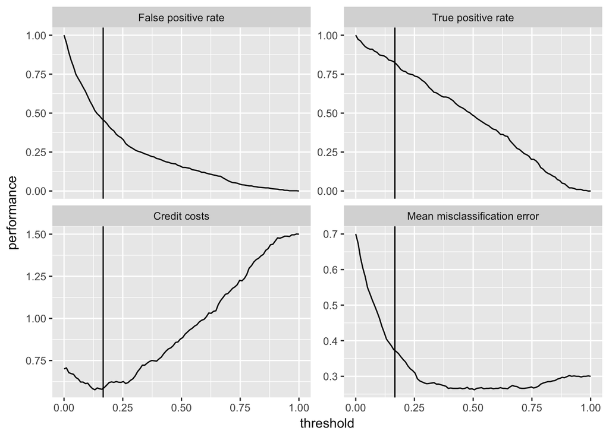

```r
ld = generateThreshVsPerfData(logisticR, measures = list(fpr, tpr, credit.costs, mmce))
plotThreshVsPerf(ld, mark.th = th)
```

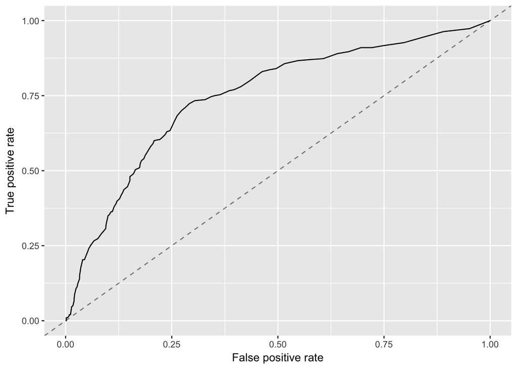

```r
plotROCCurves(ld)
```

```r
performance(logisticR$pred, credit.costs)
```

```
## credit.costs
##        0.579
```

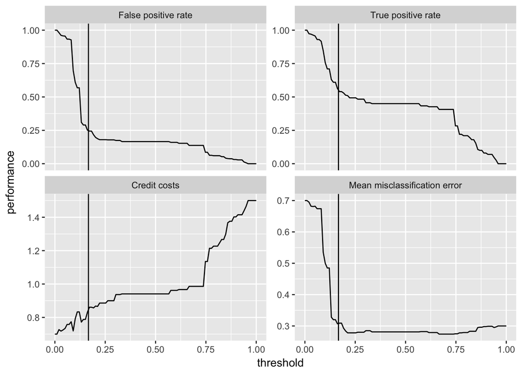

```r
cd = generateThreshVsPerfData(c50R, measures = list(fpr, tpr, credit.costs, mmce))
plotThreshVsPerf(cd, mark.th = th)
```

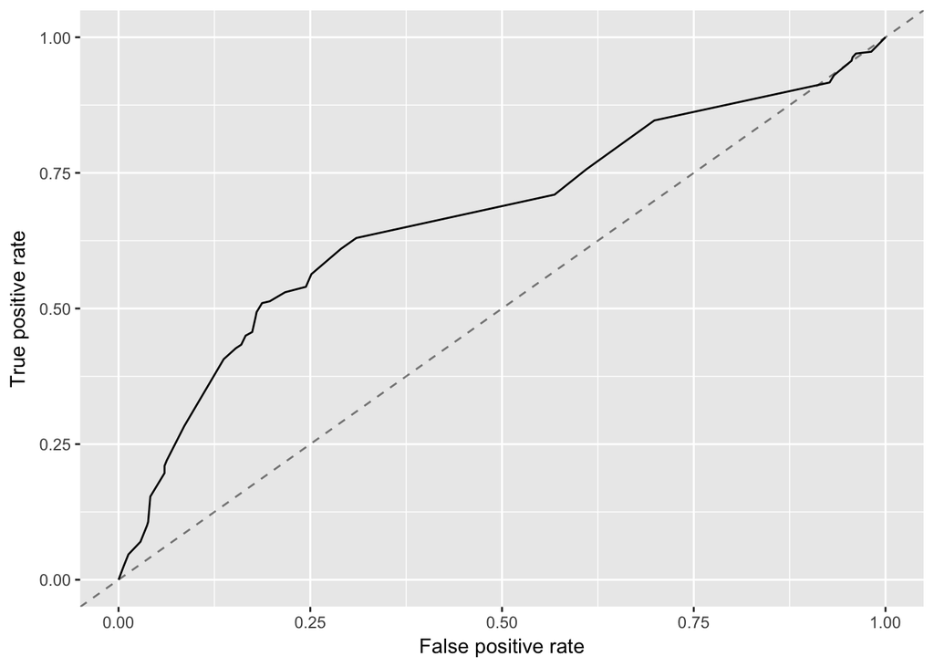

```r
plotROCCurves(cd)
```

```r
performance(c50R$pred, credit.costs)
```

```
## credit.costs
##        0.861
```

# Learning Curve for various learners

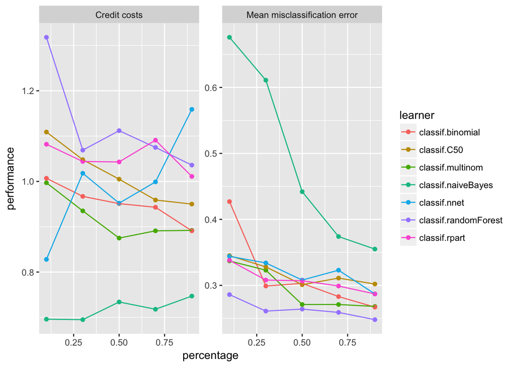

```r
r = generateLearningCurveData(
  learners = c("classif.multinom","classif.C50","classif.randomForest","classif.binomial","classif.naiveBayes","classif.nnet","classif.rpart"),
  task = credit.task,
  percs = seq(0.1, 1, by = 0.2),
  measures = list(credit.costs,mmce),
  resampling = rin,
  show.info = FALSE)
plotLearningCurve(r)
```

# RandomForest model:

```r
Randomlrn = makeLearner("classif.randomForest", predict.type = "prob", fix.factors.prediction = TRUE)
rin = makeResampleInstance("CV", iters = 5, task = credit.task,stratify=TRUE)
Ranr = resample(Randomlrn, credit.task, rin, measures = list(credit.costs, mmce), show.info = FALSE)
Ranr
```

```
## Resample Result
## Task: ml_credit_dataset
## Learner: classif.randomForest
## Aggr perf: credit.costs.test.mean=1.0660000,mmce.test.mean=0.2540000
## Runtime: 14.1093
```

Prediction based on theoretical threshold

```r
Ranpred.th = setThreshold(Ranr$pred, threshold = th)
calculateConfusionMatrix(Ranpred.th)
```

```
##         predicted
## true     Bad Good -err.-
##   Bad    281   19     19
##   Good   436  264    436
##   -err.- 436   19    455
```

```r
performance(Ranpred.th, measures = list(credit.costs, mmce))
```

```
## credit.costs         mmce
##        0.531        0.455
```

Tuning Threshold

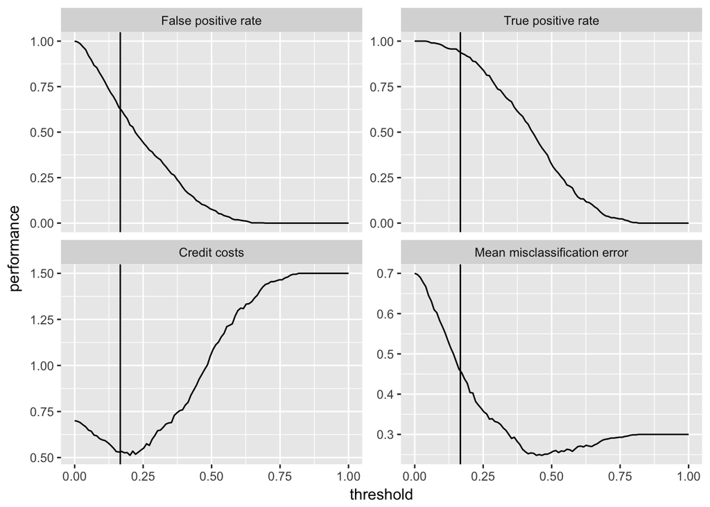

```r
dr = generateThreshVsPerfData(Ranr, measures = list(fpr, tpr, credit.costs, mmce))
plotThreshVsPerf(dr, mark.th = th)
```

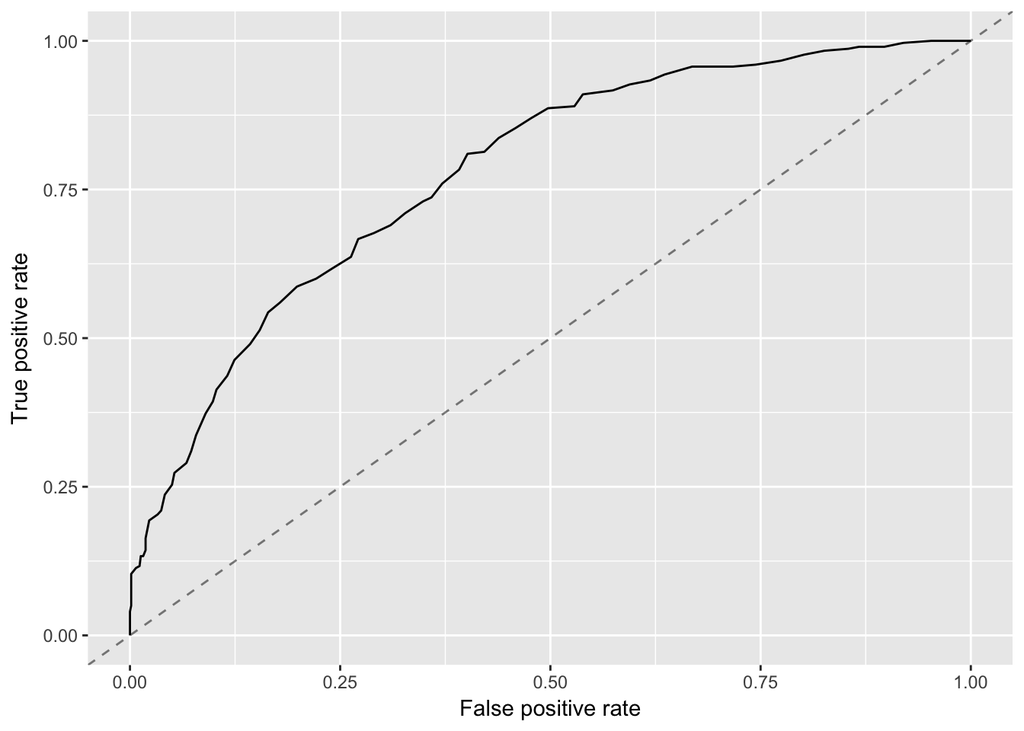

```r
plotROCCurves(dr)
```

```r
performance(Ranr$pred,credit.costs)
```

```
## credit.costs
##        1.066
```

# Naive Bayes Model:

```r
NBlrn = makeLearner("classif.naiveBayes", predict.type = "prob", fix.factors.prediction = TRUE)
rin = makeResampleInstance("CV", iters = 5, task = credit.task,stratify=TRUE)
NBr = resample(NBlrn, credit.task, rin, measures = list(credit.costs, mmce), show.info = FALSE)
NBr
```

```
## Resample Result
## Task: ml_credit_dataset
## Learner: classif.naiveBayes
## Aggr perf: credit.costs.test.mean=0.8770000,mmce.test.mean=0.3330000
## Runtime: 1.79468
```

```r
NBpred.th = setThreshold(NBr$pred, threshold = th)
calculateConfusionMatrix(NBpred.th)
```

```
##         predicted
## true     Bad Good -err.-
##   Bad    181  119    119
##   Good   228  472    228
##   -err.- 228  119    347
```

```r
performance(NBpred.th, measures = list(credit.costs, mmce))
```

```
## credit.costs         mmce
##        0.823        0.347
```

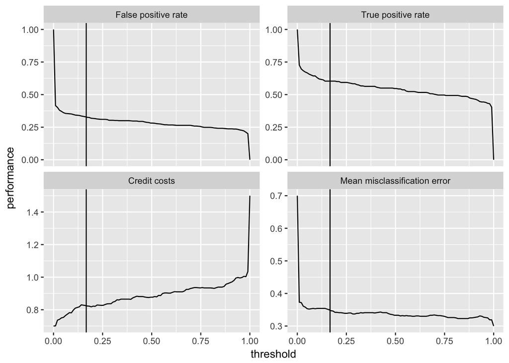

```r
Nr = generateThreshVsPerfData(NBr, measures = list(fpr, tpr, credit.costs, mmce))
plotThreshVsPerf(Nr, mark.th = th)
```

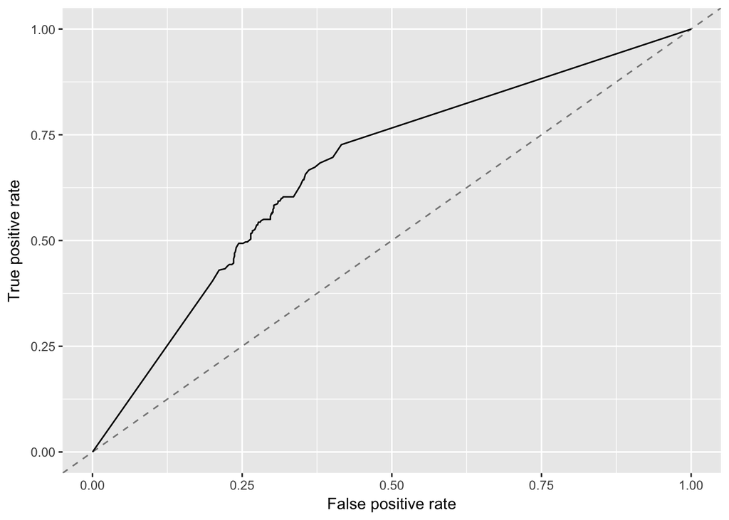

```r
plotROCCurves(Nr)
```

```r
performance(NBr$pred,credit.costs)
```

```
## credit.costs
##        0.877
```

# Binomial Model

```r
Blrn = makeLearner("classif.binomial", predict.type = "prob", fix.factors.prediction = TRUE)
rin = makeResampleInstance("CV", iters = 5, task = credit.task,stratify=TRUE)
Br = resample(Blrn, credit.task, rin, measures = list(credit.costs, mmce), show.info = FALSE)
Br
```

```
## Resample Result
## Task: ml_credit_dataset
## Learner: classif.binomial
## Aggr perf: credit.costs.test.mean=0.8910000,mmce.test.mean=0.2670000
## Runtime: 0.942187
```

```r
Bpred.th = setThreshold(Br$pred, threshold = th)
calculateConfusionMatrix(Bpred.th)
```

```
##         predicted
## true     Bad Good -err.-
##   Bad    255   45     45
##   Good   308  392    308
##   -err.- 308   45    353
```

```r
performance(Bpred.th, measures = list(credit.costs, mmce))
```

```
## credit.costs         mmce
##        0.533        0.353
```

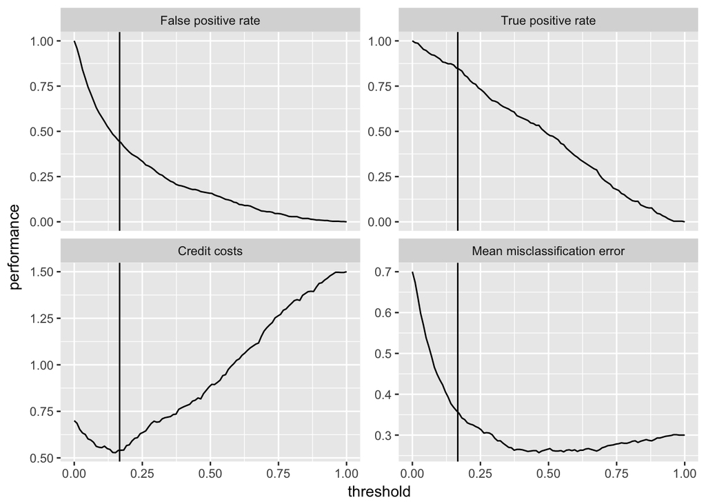

```r
Bir = generateThreshVsPerfData(Br, measures = list(fpr, tpr, credit.costs, mmce))
plotThreshVsPerf(Bir, mark.th = th)
```

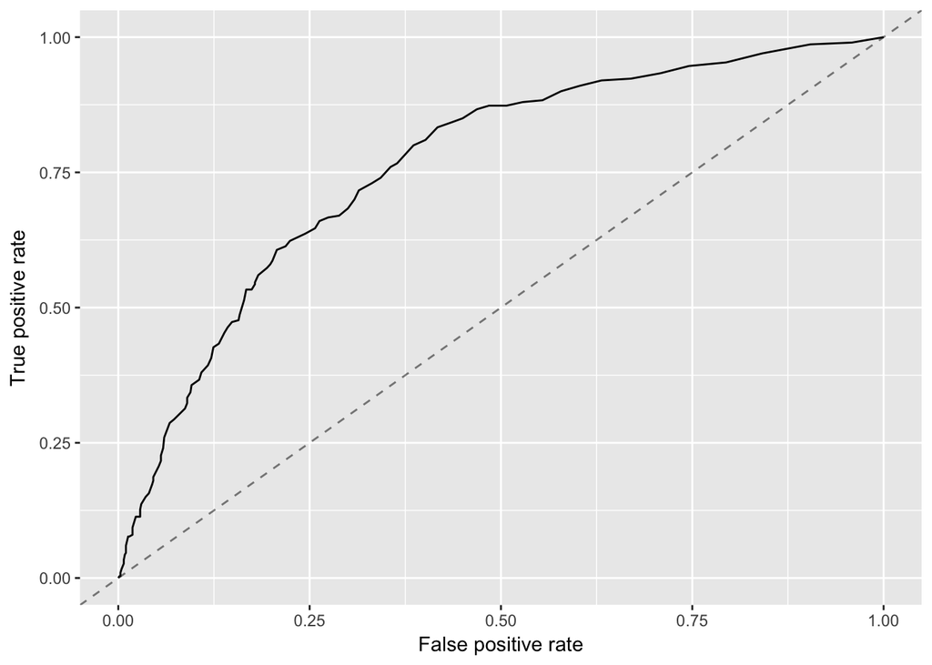

```r
plotROCCurves(Bir)
```

```r
performance(Br$pred,credit.costs)
```

```
## credit.costs
##        0.891
```

# Neural Net Model

```r
NNetlrn = makeLearner("classif.nnet", predict.type = "prob", fix.factors.prediction = TRUE)
rin = makeResampleInstance("CV", iters = 5, task = credit.task,stratify=TRUE)
NNetr = resample(NNetlrn, credit.task, rin, measures = list(credit.costs, mmce), show.info = FALSE)
NNetr
```

```
## Resample Result
## Task: ml_credit_dataset
## Learner: classif.nnet
## Aggr perf: credit.costs.test.mean=0.9240000,mmce.test.mean=0.2840000
## Runtime: 1.32807
```

```r
NNpred.th = setThreshold(NNetr$pred, threshold = th)
calculateConfusionMatrix(NNpred.th)
```

```
##         predicted
## true     Bad Good -err.-
##   Bad    186  114    114
##   Good   199  501    199
##   -err.- 199  114    313
```

```r
performance(NNpred.th, measures = list(credit.costs, mmce))
```

```
## credit.costs         mmce
##        0.769        0.313
```

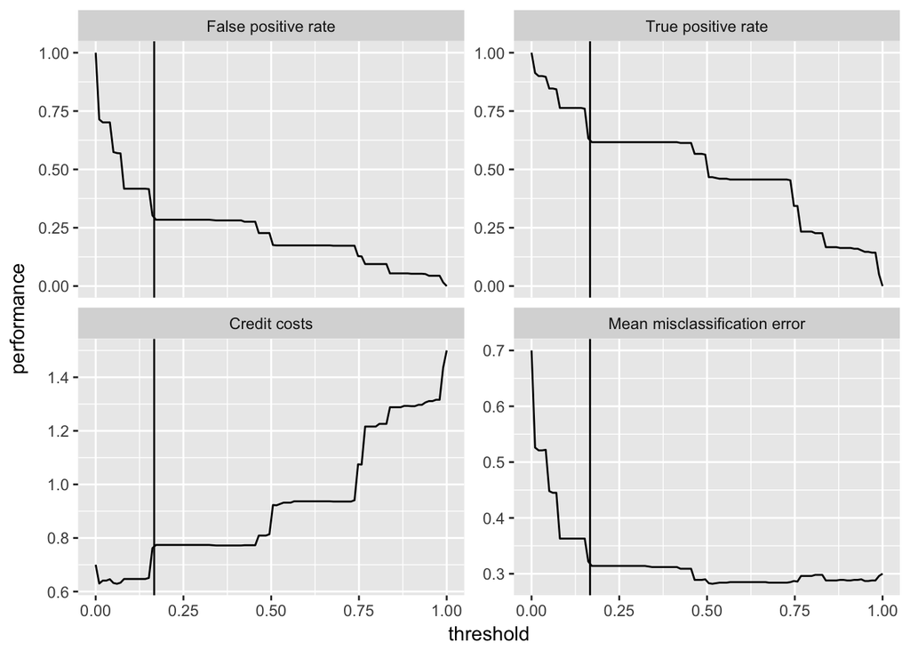

```r
NNr = generateThreshVsPerfData(NNetr, measures = list(fpr, tpr, credit.costs, mmce))
plotThreshVsPerf(NNr, mark.th = th)
```

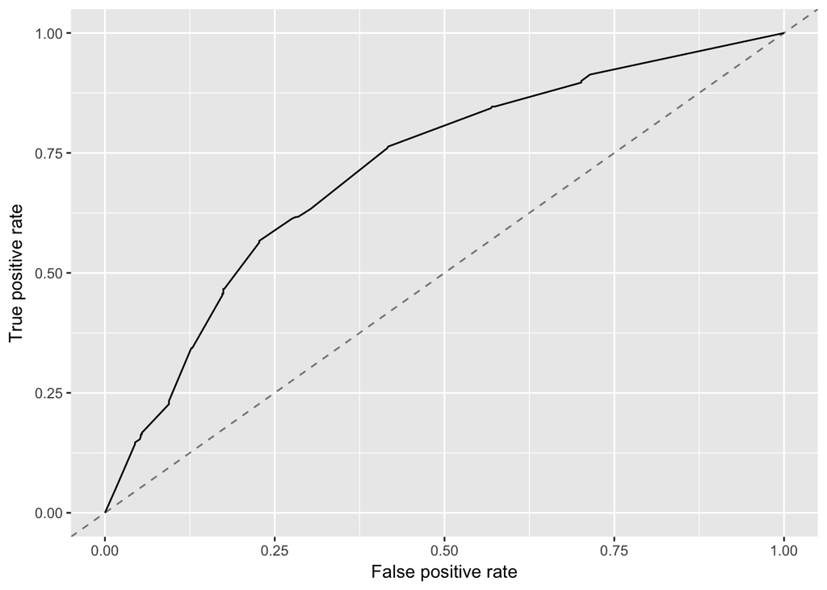

```r
plotROCCurves(NNr)
```

```r
performance(NNetr$pred,credit.costs)
```

```
## credit.costs
##        0.924
```